# Chapter 2: Statistical Learning

Notes from ISL

Sven Halvorson

7/9/2020

### Definitions

2.1

2.2

### Notes

#### 2.1: What is statistical learning?

At it’s broadest, the goal of this book is to look at techniquest to estimate a function that connects a set of $p$ predictors, $X = (X_1, X_2, ..., X_p)$ and the response $Y$. This is written as:

$$Y = f(X) + \epsilon$$
In general, $f$ is not known but there are many methods to try and approximate it.

The motivation to do so falls broadly under two categories: prediction and inference. Prediction problems occur when we have a sample of the possible inputs and outputs and would like to guess outputs from another sample of inputs. In these predictions, $\hat{Y}$, we will have average square errors for a given estimate of $f$, $\hat{f}$, that are of this form:

The second setting described is inference which is more descriptive and scientific. Here we’re asking questions like what is the relationship (if any) between $X$ and $Y$l? What kind of quantitative exchanges can we make between $X$ and $Y$? These problems are more dependent on interpretation and thus we will frequently choose less flexible models to solve them.

A distinction between flexible and interpretable models is given with the example of parametric vs. non-parametric models. Parametric models begin by assuming the general functional form of $f$ and then estimate the parameters necessary using the training data. As a result of being able to estimate the functional form of $f$, we can write better sentences about the relationship between $X$ and $Y$ and thus they are more interpretable and well suited for inference problems. The drawback of this is that the functional form may only fit a few situations and thus is not flexible. As a result, non-parametric methods can be stronger in the cases but they often lack interpretable results from the ‘black-box’ approach. Non-parametric models tend to require a larger number of observations because the problem is not reduced to a question of estimating a few parameters.

We’re also given a distinction between supervised and unsupervised learning. Supervised learning occurs in the situations previously mentioned: prediction and inference. Here we have some set of observed values, $Y$, that we would like to know more about. The converse is unsupervised learning where no response variable is observed. In this case, we’re asking if there are any natural groupings we can give the observations based on $X$. As a result this is sometimes called clustering or cluster analysis. The results of this analysis could lead to results in personalized medicine or targeted advertising.

#### 2.2: Assessing model accuracy

Given that there are many possible models for a set of predictors and responses, it’s important to compare their accuracy. One commonly used measure is the mean square error which, as its name suggests, is the average square deviation between the responses and predictions:
$$MSE = \frac{1}{n}\sum_{i=1}^n(y_i-\hat{f}(x_i))^2$$

This is basically the variance of the errors and I suspect it is preferred over the mean absolute deviation for algebraic reasons. The MSE can be computed on both the training and test data but it is much more important in the latter case. An estimate of $f$ that has a low training MSE may be overfit and not translate well to new data. Selecting more and more flexible methods will typically decrease the training MSE but at some point the test MSE will start to rise as the model becomes overfit.

The conflict between minimizing training MSE and overfitting can be shown in the test expected MSE for a $x_0$ not in the training set:
$$E(y_0-\hat{f}(x_0))^2=Var(\hat{f}(x_0)) + Bias(\hat{f}(x_0))^2+Var(\epsilon)$$
Here the expected test MSE would be formed by estimating $\hat{f}$ using many training sets and averaging the square deviations of the predictions from $y_0$. This shows that we can subdivide the expected test MSE into three sources. One of which cannot be affeted for a given set of predictors, the irreducible error, but the others can. Our goal is to reduce the variance of the method and the bias however they are sometimes in conflict.

The variance refers to the degree to which $\hat{f}$ changes across many possible training sets. Flexible methods tend to have high degrees of variance because they are less constrained and tend to fit the data more closely. Bias refers to the ways in which the assumptions of the model differ from reality. Fitting a simple linear model to data produced by a quadratic function will have a higher degree of bias than it would if the data came from a roughly linear phenomenon. Less flexible methods typically produce more bias.

There is an analogous irreducible error for the classification setting called the Bayes error rate. This can be expressed as:
$$\textrm{Bayes error rate}=1-E(\mathop{max}_{i}P(Y=j|X))$$
It’s saying that for each observation in the training set, we compute the probability associated with the most likely category to assign, take expectation of that and then the converse of it. My gripe with the notation here continues as I would think you need a set of parentheses around max but I guess I’ll just let it go here and try to infer what they mean in general going forward.

The last piece of this chapter is a discussion of the k-nearest neighbors algorithm. This is an alogrithm for classification (although I believe it can be extended to regression) where for a test observation $x_0$, we select a natural number $K$ and find the set of $K$ ‘closest’ points in the training set, $\mathcal{N}_0$. Then we basically average the indicator functions of all the elements of $\mathcal{N}_0$ and then take the class $Y=j$ which has the highest probability as our classification. Compute this quantity for each category $Y=j$:

$$P(Y=j) = \frac{1}{K}\sum_{i\in\mathcal{N}_0}I(y_i=j)$$

Whichever has the highest is our classification. This should end up with ties some of the time so that will be the Bayes decision boundary for the algorithm. It seems like it might be kind of sticky when we get to situations with many different categories as the pariwise boundaries will be all higgldy piggldy.

The name of this algorithm makes me think about actual geography. We could think of a situation where we just use latitude and longitude as predictors for someone’s political affiliation. If you were looking at a neighborhood that was predominately, but not homogeneously one party, you would not want to just ask for their literal nearest neighbor. I can imagine situation where there is one house in the center which is of the minority party and then three majority members around it that are all three closer to the center than they are to each other. If that middle house was a minority member in the training set, we would assign all three of the surrounding houses to the minority party. On the other hand, if we got a larger set, the influence of that one minority house will be less influential. On the other hand, if we pick $K$ to be the entire training set, we will basically guessing the global frequencies and ignoring any geographic patterns in party affilition.

I have a few questions about this algorithm and I think it is re-visted in the book so I’ll just leave them here for now: 1. I imagine there are other definitions of distance other than the Euclidean one. Are there advantages to using soemthing like the taxicab metric? 2. It seems like you would want to have all the variables on the same scale, otherwise the units of one variable could have an outsized effect on which training observations fall into $\mathcal{N}_0$. I imagine people standardize or normalize data before using this technique. 3. Is there a way to use categorical variables and mix them with continous variables? The idea of distance makes this a bit hard.

### Lab

I think I’ll just skip this first lab as it looks like just an introduction to R.

### Exercises

1. Determine whether a flexible or inflexible method would be preferred in these situations:
   1. If the sample size is large and the number of predictors is small, a flexible method would be preferred. A larger sample size would lend itself better to flexible non-parametric methods. Having fewer predictors also reduces the risk of overfitting.
   2. If the sample size is small and the number of predictors is large, we would prefer a less flexible method. Flexible methods are likely to see patterns when none exist in this situation.
   3. If the relationship between preidctors and responses is highly non-linear we *might* prefer a more flexible method. I think this is probably the answer the authors intend but it depends on what kind of non-linear relationship we’re talking about. If it’s a relatively simple non-linear pattern, like a quadratic function, then a inflexible method like linear regression with a squared term could work just fine. I think in a lot of non-linear situations we are going to want a more flexible method though.
   4. If the variance of the error term is extremely high we would probably prefer a less flexible method. A larger irreducible error means that flexible methods will respond to this more acutely and not pick out broader trends.
2. Categorize these situations as regression or classification and identify $n$ and $p$
   1. A set of 500 firms ($n$), with three features ($p$), predicting CEO salary (regression).
   2. Determinining the success or failure (classification) from 13 predictors ($p$) from a sample of 20 ($n$) similar products.
   3. Predicting the percent change in USA/Euro exchange rate (regression) from 52 weeks of data ($n$) using three ($p$) markets data.
3. Create a rough sketch of a typical plot of square bias, training error rate, testing error rate, and Bayes error rate vs the flexibility of the model.

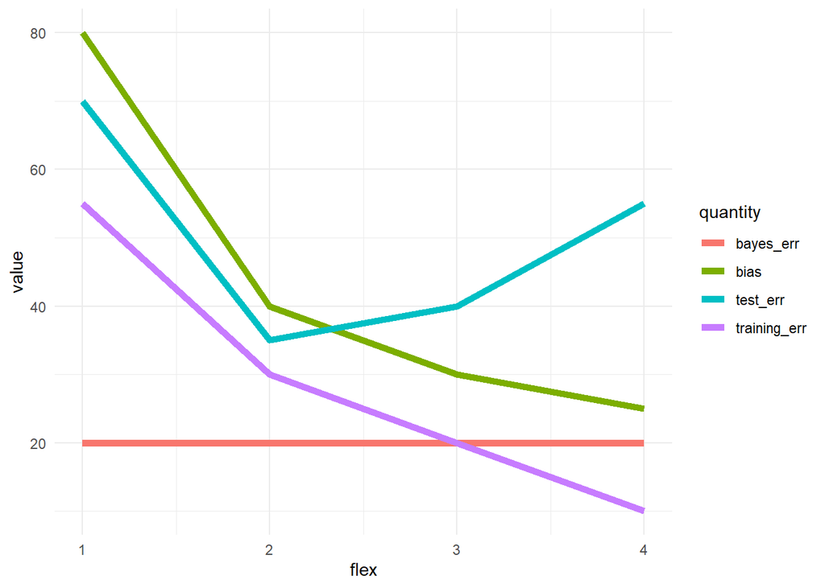

The Bayes error is fixed at a particular level when you select $Y$ and $X$ so it is flat. The bias monotonically decreases as bias is due to assumptions about models. These assumptions are peeled away as flexibility increases. Testing error decreases at first as some bias is removed but then increases as the variance of the model goes up. The training error only decreases as models become more tuned to the data set used to create them.

4. Think of some real life situations to use prediction, inference, and cluster analysis.
   1. Prediction
      1. Guessing which patients will need postoperative blood transfusions.
      2. Predicting which candidates will be effective after hiring.
      3. Trying to screen spam email.
   2. Inference
      1. Estimating the association between preoperative anemia and need for postoperative blood transfusions.
      2. Determining which factors are highly predictive of effective employees.
      3. Finding the important characteristics of a spam email.
   3. Clustering
      1. Looking for phenotypes of anemic patients
      2. Categorizing employees at a large organization
      3. Clustering types of scams.
5. Cases in which you might want a less flexible method include:
   - When inference is the goal
   - When the observed relationship between predictors and responses is relatively simple
   - When the number of predictors is relatively few or the number of observations is small Cases when we might want a more flexible approach:
   - When the relationship between predictors and response is highly complex/nonlinear
   - When the number of observations is large
   - When the goal is not inference
6. Parametric approaches assume some form of the predictor-response relationship that relies on one or more parameters. The training set is then used to estimate those parameters and predictions are made from the estimated function. Non-parametric approaches do not make such assumptions about the predictor/response relationship. Parametric methods are generally preferred when inference is the goal because it is easier to make quantitative (or even qualitative) statements about the predictor-response relationship. These methods tend to be inflexible and when relationships are complex, non-parametric may be preferred.
7. Consider using KNN for a point $X_1 = X_2 = X_3 = 0$ using the training set below:

| X1 | X2 | X3 | Y |
| --- | --- | --- | --- |
| 0 | 3 | 0 | red |
| 2 | 0 | 0 | red |
| 0 | 1 | 3 | red |
| 0 | 1 | 2 | green |
| -1 | 0 | 1 | green |
| 1 | 1 | 1 | red |

1. Compute the Euclidean distance from the test point to each point:

| X1 | X2 | X3 | Y | dist |
| --- | --- | --- | --- | --- |
| 0 | 3 | 0 | red | 3.000000 |
| 2 | 0 | 0 | red | 2.000000 |
| 0 | 1 | 3 | red | 3.162278 |
| 0 | 1 | 2 | green | 2.236068 |
| -1 | 0 | 1 | green | 1.414214 |
| 1 | 1 | 1 | red | 1.732051 |

2. What are the classifications for $K=1$ and $K=3$? For each of these we need to compute $P(Y = green)$. For $K=1$, it’s 1 because the closest value is green so we classify it as green. For $K=3$, two of the three closest values a red so $P(Y = green) = \frac{1}{3}$ and we assign red.
   4. If the Bayes decision boundary for this kind of problem is highly non-linear, then the categories may be clumped in some less clear ways. As a result, we could end up with islands of one category that are far from the rest of their group. As a result, smaller values of $K$ may be preferred.